# Dominic DeCoster

## Midterm Revision

### Romer-Solow Model

#### 1) Calculate the average growth rate of TFP and Population over the last 50 years.

$n_{avg}$ = $(\frac {L_t}{L_0})^\frac{1}{t} -1$

$g_{avg}$ = $(\frac {A_t}{A_0})^\frac{1}{t} -1$

```python
g_avg= (((1.03053)/(0.78337))**(1/50))-1
n_avg= (((205690000)/(116875000))**(1/50))-1

print("Average growth rate of TFP over 50 years: g=",'{:.4f}'.format(g_avg))
print("Average growth rate of population over 50 years: n=",'{:.4f}'.format(n_avg))

#TFP in Fred only goes to 2017, so 50 years from there is 1967
```

```
Average growth rate of TFP over 50 years: g= 0.0055
Average growth rate of population over 50 years: n= 0.0114
```

#### 2) Solve for the value of $k^* = \frac{K}{A*L}$ in the steady-state, $k^*$.

$k_t^*$ $=$ $(1-{\ell})$$(\frac{s}{\delta + g + n})^{\frac{1}{1-a}}$

```python
s=0.1
d= 0.06
a= 0.33
l= 0.01

g= g_avg
n= n_avg

k_star= (1-l)*((s/(d+g+n))**(1/(1-a)))
print("The amount of capital per capita in steady state: k*=",'{:.3f}'.format(k_star))
```

```
The amount of capital per capita in steady state: k*= 1.466
```

#### 3) Implement the Solow-Romer model in Python using the parameter values from question 2.

#### 3a: Phase Diagram

```
capital per capita (k*): 1.466
output per capita (y*):1.105
```

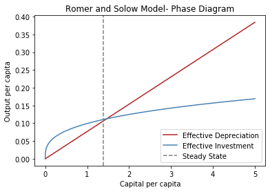

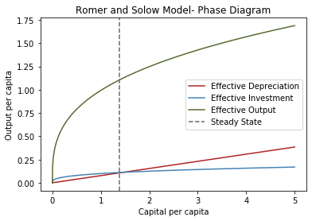

```python
## This is the Phase Diagram from class, showing "per capita steady-state"

import numpy as np
import matplotlib.pyplot as plt

s=0.1
d= 0.06
a= 0.33
l= 0.01

g= g_avg
n= n_avg

k= np.linspace (0,5, num= 1000)

Dep= []
Inv= []
Out= []

for i in range (len(k)):
    D= (d+g+n)*k[i]
    Dep.append(D)
for i in range(len(k)):
    I= s*((1-l)**(1-a))*(k[i]**a)
    Inv.append(I)
for i in range(len(k)):
    Y= (1-l)**(1-a)*(k[i]**a)
    Out.append(Y)

print("capital per capita (k*): 1.466")
print("output per capita (y*):1.105")
print()

plt.plot(k,Dep, c="firebrick", label= "Effective Depreciation")
plt.plot(k,Inv, c="steelblue", label= "Effective Investment")
plt.title("Romer and Solow Model- Phase Diagram")
plt.axvline(x=1.38, c= "grey", linestyle="--", label= "Steady State")
plt.xlabel("Capital per capita")
plt.ylabel("Output per capita")
plt.legend()
plt.show()

plt.plot(k,Dep, c="firebrick", label= "Effective Depreciation")
plt.plot(k,Inv, c="steelblue", label= "Effective Investment")
plt.plot(k,Out, c="darkolivegreen", label= "Effective Output")
plt.axvline(x=1.38, c= "dimgrey", linestyle="--", label= "Steady State")
plt.title("Romer and Solow Model- Phase Diagram")
plt.xlabel("Capital per capita")
plt.ylabel("Output per capita")
plt.legend()
plt.show()
```

#### 3b: Suppose that K0=1,000, L0=500, and A0=1.7.

#### How long does it take the model to reach the steady-state?

#### Graph the path of Kt, Yt, Ct from their initial values until 10 periods after they reach the steady-state value of k. Use the log scale.

#### What are the values of Kt, Lt, At once they first reached the steady-state?

```
Time needed to reach steady state: 69 years

Capital at steady state: 3942.07
Labor at steady state: 1090.81
TFP at steady state: 2.48
```

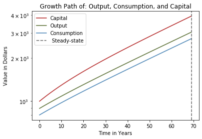

```python
## Using Romer/Solow to show Output, Capital, and Consumption:

import numpy as np
import matplotlib.pyplot as plt


#Step 1: Define the production function that combines Romer/Solow
def production_func (l, A, K, L, a):
    return (((1 - l) ** (1 - a)) * (A ** (1 - a)) * (K ** a) * (L ** (1 - a)))

#Step 2: Define the inital variables
K0 = 1000
L0 = 500
A0 = 1.7

#Step 3: Define our variables as arrays
Capital = [K0]                                       #big K= Capital
Labor = [L0]                                         #L= Labor
TFP = [A0]                                           #TFP= Knowledge
Output = [production_func(l, A0, K0, L0, a)]
Consumption = [(1-s) * Output[0]]                    #Consumption= (1-s)*Y [page 7: Moncayo's notes]
little_k = [K0 / (A0 * L0)]                          #little k = capital per person

#Step 4: Define time and periods:
t = 0
period = [t]


#Step 5: Set up loop:

while abs(little_k[t] - 1.466) > .01:
    Capital= np.append(Capital, Capital[t] + (s * Output[t] - d * Capital[t]))
    Labor= np.append(Labor, Labor[t] * (1 + n))
    TFP= np.append(TFP, TFP[t] * (1 + g))
    Output= np.append(Output, production_func(l, TFP[t+1], Capital[t+1], Labor[t+1], a))
    Consumption= np.append(Consumption, (1-s)*Output[t+1])
    little_k= np.append(little_k, Capital[t+1] / (TFP[t+1] * Labor[t+1]))
    t += 1
    period.append(t)

#Step 6: Print values from question:
print("Time needed to reach steady state: {} years" .format(t))
print()
print("Capital at steady state: {:.2f}" .format(Capital[-1]))
print("Labor at steady state: {:.2f}" .format(Labor[-1]))
print("TFP at steady state: {:.2f}" .format(TFP[-1]))
print()


#Step 7: Print graph:
plt.plot(period, Capital,c= "firebrick", label = "Capital")
plt.plot(period, Output, c="darkolivegreen", label = "Output")
plt.plot(period, Consumption, c= "steelblue", label = "Consumption")
plt.axvline(x=t, color = "dimgrey", linestyle = "--", label = " Steady-state")
plt.title("Growth Path of: Output, Consumption, and Capital")
plt.yscale('log')
plt.xlabel("Time in Years")
plt.ylabel("Value in Dollars")
plt.legend()
plt.show()
```

#### 4) Conduct comparative static numerical simulations.

a) War destroys half of the capital (K) in the US.

b) Millennials suddenly increase their savings rate, doubling the historical average.

c) A peaceful advanced extraterrestrial race gives the US technology that instantly doubles TFP

d) A scenario of your making: WW3 is declared and a quarter of the workforce goes to war

#### a) War destroys half of the capital (K) in the US.

```
Time needed to return to steady state: 97 years
Steady-State k*: 1.37
```

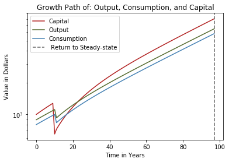

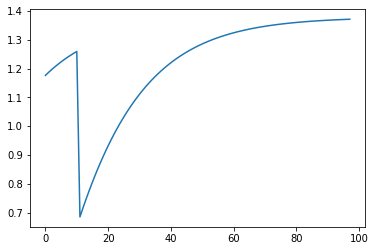

```python
def production_func (l, A, K, L, a):
    return (((1 - l) ** (1 - a)) * (A ** (1 - a)) * (K ** a) * (L ** (1 - a)))
s=0.1
d= 0.06
a= 0.33
l= 0.01

g= 0.01
n=0.01

K0 = 1000
L0 = 500
A0 = 1.7

Capital = [K0]                                       #big K= Capital
Labor = [L0]                                         #L= Labor
TFP = [A0]                                           #TFP= Knowledge
Output = [production_func(l, A0, K0, L0, a)]
Consumption = [(1-s) * Output[0]]                    #Consumption= (1-s)*Y [page 7: Moncayo's notes]
little_k = [K0 / (A0 * L0)]                          #little k = capital per person

t = 0
period = [t]
i=0

for t in range (0,10):
    Capital= np.append(Capital, Capital[t] + (s * Output[t] - d * Capital[t]))
    Labor= np.append(Labor, Labor[t] * (1 + n))
    TFP= np.append(TFP, TFP[t] * (1 + g))
    Output= np.append(Output, production_func(l, TFP[t+1], Capital[t+1], Labor[t+1], a))
    Consumption= np.append(Consumption, (1-s)*Output[t+1])
    little_k= np.append(little_k, Capital[t+1] / (TFP[t+1] * Labor[t+1]))
    t += 1
    period.append(t)

#Capital is cut in half at 10 years:
Capital[t]= Capital[t]/2

while abs(little_k[t] - 1.381) > .01:
    Capital= np.append(Capital, Capital[t] + (s* Output[t]- d*Capital[t]))
    Labor= np.append(Labor, Labor[t] * (1 + n))
    TFP= np.append(TFP, TFP[t] * (1 + g))
    Output= np.append(Output, production_func(l, TFP[t+1], Capital[t+1], Labor[t+1], a))
    Consumption= np.append(Consumption, (1-s)*Output[t+1])
    little_k= np.append(little_k, Capital[t+1] / (TFP[t+1] * Labor[t+1]))
    t += 1
    period.append(t)

print("Time needed to return to steady state: {} years" .format(t))
print("Steady-State k*: {:.2f}" .format(Capital[-1] / (TFP[-1] * Labor[-1])))
print()


plt.plot(period, Capital,c= "firebrick", label = "Capital")
plt.plot(period, Output, c="darkolivegreen", label = "Output")
plt.plot(period, Consumption, c= "steelblue", label = "Consumption")
plt.axvline(x=t, color = "dimgrey", linestyle = "--", label = " Return to Steady-state")
plt.title("Growth Path of: Output, Consumption, and Capital")
plt.yscale('log')
plt.xlabel("Time in Years")
plt.ylabel("Value in Dollars")
plt.legend()
plt.show()

plt.plot(period, little_k)
plt.show()
```

#### b) Millennials suddenly increase their savings rate, doubling the historical average.

```
3.8866506503958753
Time needed to return to steady state: 110 years
Steady-State k*: 3.87
```

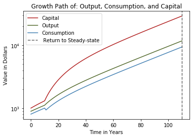

```python
def production_func (l, A, K, L, a):
    return (((1 - l) ** (1 - a)) * (A ** (1 - a)) * (K ** a) * (L ** (1 - a)))
s=0.1
d= 0.06
a= 0.33
l= 0.01

g= 0.01
n=0.01

K0 = 1000
L0 = 500
A0 = 1.7

Capital = [K0]                                       #big K= Capital
Labor = [L0]                                         #L= Labor
TFP = [A0]                                           #TFP= Knowledge
Output = [production_func(l, A0, K0, L0, a)]
Consumption = [(1-s) * Output[0]]                    #Consumption= (1-s)*Y [page 7: Moncayo's notes]
little_k = [K0 / (A0 * L0)]                          #little k = capital per person

t = 0
period = [t]
i=0

for t in range (0,10):
    Capital= np.append(Capital, Capital[t] + (s * Output[t] - d * Capital[t]))
    Labor= np.append(Labor, Labor[t] * (1 + n))
    TFP= np.append(TFP, TFP[t] * (1 + g))
    Output= np.append(Output, production_func(l, TFP[t+1], Capital[t+1], Labor[t+1], a))
    Consumption= np.append(Consumption, (1-s)*Output[t+1])
    little_k= np.append(little_k, Capital[t+1] / (TFP[t+1] * Labor[t+1]))
    t += 1
    period.append(t)

#Savings is doubled at 10 years:
#s=[0.1]
#s[t]= s[t]*2
s= s*2
k_star= (1-l)*((s/(d+g+n))**(1/(1-a)))
print(k_star)

while abs(little_k[t] - 3.89) > .025:
    Capital= np.append(Capital, Capital[t] + (s * Output[t]- d*Capital[t]))
    Labor= np.append(Labor, Labor[t] * (1 + n))
    TFP= np.append(TFP, TFP[t] * (1 + g))
    Output= np.append(Output, production_func(l, TFP[t+1], Capital[t+1], Labor[t+1], a))
    Consumption= np.append(Consumption, (1-s)*Output[t+1])
    little_k= np.append(little_k, Capital[t+1] / (TFP[t+1] * Labor[t+1]))
    t += 1
    period.append(t)

print("Time needed to return to steady state: {} years" .format(t))
print("Steady-State k*: {:.2f}" .format(Capital[-1] / (TFP[-1] * Labor[-1])))
print()

plt.plot(period, Capital,c= "firebrick", label = "Capital")
plt.plot(period, Output, c="darkolivegreen", label = "Output")
plt.plot(period, Consumption, c= "steelblue", label = "Consumption")
plt.axvline(x=t, color = "dimgrey", linestyle = "--", label = " Return to Steady-state")
plt.title("Growth Path of: Output, Consumption, and Capital")
plt.yscale('log')
plt.xlabel("Time in Years")
plt.ylabel("Value in Dollars")
plt.legend()
plt.show()
```

#### c) A peaceful advanced extraterrestrial race gives the US technology that instantly doubles TFP

```
Time needed to return to steady state: 98 years
Steady-State k*: 1.37
```

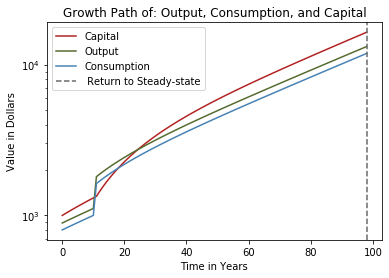

```python
def production_func (l, A, K, L, a):
    return (((1 - l) ** (1 - a)) * (A ** (1 - a)) * (K ** a) * (L ** (1 - a)))
s=0.1
d= 0.06
a= 0.33
l= 0.01

g= 0.01
n=0.01

K0 = 1000
L0 = 500
A0 = 1.7

Capital = [K0]                                       #big K= Capital
Labor = [L0]                                         #L= Labor
TFP = [A0]                                           #TFP= Knowledge
Output = [production_func(l, A0, K0, L0, a)]
Consumption = [(1-s) * Output[0]]                    #Consumption= (1-s)*Y [page 7: Moncayo's notes]
little_k = [K0 / (A0 * L0)]                          #little k = capital per person

t = 0
period = [t]
i=0

for t in range (0,10):
    Capital= np.append(Capital, Capital[t] + (s * Output[t] - d * Capital[t]))
    Labor= np.append(Labor, Labor[t] * (1 + n))
    TFP= np.append(TFP, TFP[t] * (1 + g))
    Output= np.append(Output, production_func(l, TFP[t+1], Capital[t+1], Labor[t+1], a))
    Consumption= np.append(Consumption, (1-s)*Output[t+1])
    little_k= np.append(little_k, Capital[t+1] / (TFP[t+1] * Labor[t+1]))
    t += 1
    period.append(t)

#Technology is doubled at 10 years:
TFP[t]= TFP[t]*2

while abs(little_k[t] - 1.381) > .01:
    Capital= np.append(Capital, Capital[t] + (s* Output[t]- d*Capital[t]))
    Labor= np.append(Labor, Labor[t] * (1 + n))
    TFP= np.append(TFP, TFP[t] * (1 + g))
    Output= np.append(Output, production_func(l, TFP[t+1], Capital[t+1], Labor[t+1], a))
    Consumption= np.append(Consumption, (1-s)*Output[t+1])
    little_k= np.append(little_k, Capital[t+1] / (TFP[t+1] * Labor[t+1]))
    t += 1
    period.append(t)

print("Time needed to return to steady state: {} years" .format(t))
print("Steady-State k*: {:.2f}" .format(Capital[-1] / (TFP[-1] * Labor[-1])))
print()

plt.plot(period, Capital,c= "firebrick", label = "Capital")
plt.plot(period, Output, c="darkolivegreen", label = "Output")
plt.plot(period, Consumption, c= "steelblue", label = "Consumption")
plt.axvline(x=t, color = "dimgrey", linestyle = "--", label = " Return to Steady-state")
plt.title("Growth Path of: Output, Consumption, and Capital")
plt.yscale('log')
plt.xlabel("Time in Years")
plt.ylabel("Value in Dollars")
plt.legend()
plt.show()
```

#### d) A scenario of your making: WW3 is declared and a quarter of the workforce goes to war

```
Time needed to return to steady state: 70 years
Steady-State k*: 1.39
```

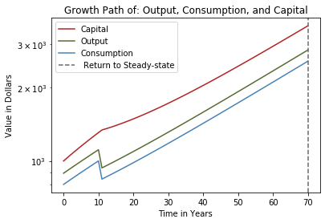

```python
def production_func (l, A, K, L, a):
    return (((1 - l) ** (1 - a)) * (A ** (1 - a)) * (K ** a) * (L ** (1 - a)))
s=0.1
d= 0.06
a= 0.33
l= 0.01

g= 0.01
n=0.01

K0 = 1000
L0 = 500
A0 = 1.7

Capital = [K0]                                       #big K= Capital
Labor = [L0]                                         #L= Labor
TFP = [A0]                                           #TFP= Knowledge
Output = [production_func(l, A0, K0, L0, a)]
Consumption = [(1-s) * Output[0]]                    #Consumption= (1-s)*Y [page 7: Moncayo's notes]
little_k = [K0 / (A0 * L0)]                          #little k = capital per person

t = 0
period = [t]
i=0

for t in range (0,10):
    Capital= np.append(Capital, Capital[t] + (s * Output[t] - d * Capital[t]))
    Labor= np.append(Labor, Labor[t] * (1 + n))
    TFP= np.append(TFP, TFP[t] * (1 + g))
    Output= np.append(Output, production_func(l, TFP[t+1], Capital[t+1], Labor[t+1], a))
    Consumption= np.append(Consumption, (1-s)*Output[t+1])
    little_k= np.append(little_k, Capital[t+1] / (TFP[t+1] * Labor[t+1]))
    t += 1
    period.append(t)

#Labor is reduced by 25% at 10 years:
Labor[t]= Labor[t]*.75

while abs(little_k[t] - 1.381) > .01:
    Capital= np.append(Capital, Capital[t] + (s* Output[t]- d*Capital[t]))
    Labor= np.append(Labor, Labor[t] * (1 + n))
    TFP= np.append(TFP, TFP[t] * (1 + g))
    Output= np.append(Output, production_func(l, TFP[t+1], Capital[t+1], Labor[t+1], a))
    Consumption= np.append(Consumption, (1-s)*Output[t+1])
    little_k= np.append(little_k, Capital[t+1] / (TFP[t+1] * Labor[t+1]))
    t += 1
    period.append(t)

print("Time needed to return to steady state: {} years" .format(t))
print("Steady-State k*: {:.2f}" .format(Capital[-1] / (TFP[-1] * Labor[-1])))
print()


plt.plot(period, Capital,c= "firebrick", label = "Capital")
plt.plot(period, Output, c="darkolivegreen", label = "Output")
plt.plot(period, Consumption, c= "steelblue", label = "Consumption")
plt.axvline(x=t, color = "dimgrey", linestyle = "--", label = " Return to Steady-state")
plt.title("Growth Path of: Output, Consumption, and Capital")
plt.yscale('log')
plt.xlabel("Time in Years")
plt.ylabel("Value in Dollars")
plt.legend()
plt.show()
```

#### 5) For each of the previous scenarios, please discuss what you found. Include details about the length of time it took to reach the steady-state of k. Was there any change in the steady-state? What do you think are the welfare consequences of each scenario occurring in real life?

$k_t^*$ $=$ $(1-{\ell})$$(\frac{s}{\delta + g + n})^{\frac{1}{1-a}}$

In each of the four scenarios, at the 10 year period some sort of shock happened. The effective steady state (k*) is a function of population growth(n), technoligcal growth(n), savings rate(s) and depreciation(d). So unless one of these factors change, the steady state should remain unchanged, with only the time to reach such steady-state fluctuating depending on the shock. Welfare consequences in real life are not going to change unless the steady-state changes. So if the steady-state remains the same there are no effects on welfare.

In the first scenario where war destroys half the capital in the US, capital drops significantly at 10 year mark, while output and consumption both decrease but not as sharply. It then takes 97 years to return to steady state, which is unchanged at 1.38 capital per capita. Welfare is unchanged in the long run once the economy has returned back to the steady-state.

These comparative statics, support that the only way to acutally change welfare in real life is to change the population growth rate, technolical growth rate, the savings rate, or depreciation. Any changes to those rates would then change welfare through the shift of the steady state values.